# beyond ggplot2, ggplot2 extensions

## Annotation

- you can’t tell story w/o words
- this has often been relegated to post processing in e.g. Adobe Illustrator
- recent improvements means that most can be done with code
- two key packages:
  - ggrepel
  - ggforce

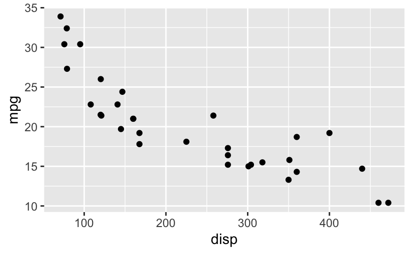

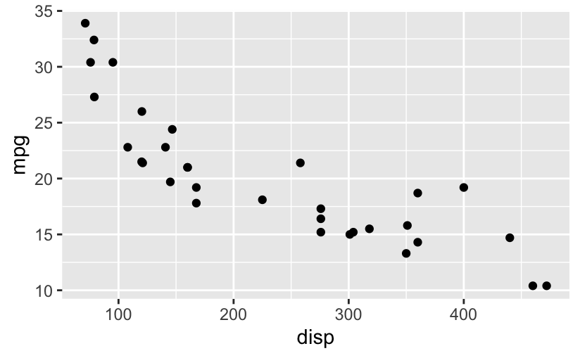

### more…

```r
install.packages('concaveman')
library(concaveman)

ggplot(mtcars, aes(x=disp, y=mpg)) +
  geom_point() +
  geom_mark_hull(aes(fill=factor(gear)))
```

[output not shown]

## network

- ggplot2 was built for tabular data

an API decision, not a grammer constraint

- multiple packages try to add network capabilities to ggplot2
- GGally
- ggnetwork
- geomnet
- ggtree
- ggdag
- ggraph

```r
library(ggraph)
library(tidygraph)

g <- create_notable('zachary') %>%
  mutate(clique=as.factor(group_infomap()))

ggraph(g) +
  geom_edge_link() +
  geom_node_point(aes(colour=clique),
                  size=2)
```

[output not shown]

## looks

theming is one of the (programmatically) easiest things to extend

lots of options: ggthemes tvthemes ggtech ggthemr hrbrthemes

often coupled with colour scales

don’t go too crazy unless warranted

[output not shown]

[output cut: 1 more lines]

## Thinking in grammer

grammer of graphics is not just for constructing graphs - use it to deconstruct as well!

the grammer is ambiguous and that’s okey

if all else fails: everything is just points, line, polygons, and text if faceting fails, use patchwork illustrator is ok

```r
anscombe
```